# Exploratory Data Analysis

Matt Cliff

April 16, 2018

This report is focused on reading several data sets, performing exploratory data analysis and saving a tidy data set to use for modeling exploration.

# Data Analysis Overview

List of https://vincentarelbundock.github.io/Rdatasets/datasets.html

We want to find something with at least 10 features, and 5000 observations [https://archive.ics.uci.edu/ml/datasets.html?format=&task=cla&att=&area=&numAtt=10to100&numIns=&type=&sort=instDown&view=table]

## Credit Payment Dataset

This comes from [card payment](https://archive.ics.uci.edu/ml/datasets/default+of+credit+card+clients) binary classifier with 23 predictors; Default of Credit Card Clients in Taiwan from 2005

The basic approach will be to ensure no zero elements NAndx <- sapply(data, function(x) mean(is.na(x))) > .9 nzv <- nearZeroVar(data)

```
   LIMIT_BAL       SEX       EDUCATION MARRIAGE       AGE
 Min.   :  10000   1:11888   0:   14   0:   54   Min.   :21.00
 1st Qu.:  50000   2:18112   1:10585   1:13659   1st Qu.:28.00
 Median : 140000             2:14030   2:15964   Median :34.00
 Mean   : 167484             3: 4917   3:  323   Mean   :35.49
 3rd Qu.: 240000             4:  123             3rd Qu.:41.00
 Max.   :1000000             5:  280             Max.   :79.00
                             6:   51
     PAY_0             PAY_2             PAY_3             PAY_4
 Min.   :-2.0000   Min.   :-2.0000   Min.   :-2.0000   Min.   :-2.0000
 1st Qu.:-1.0000   1st Qu.:-1.0000   1st Qu.:-1.0000   1st Qu.:-1.0000
 Median : 0.0000   Median : 0.0000   Median : 0.0000   Median : 0.0000
 Mean   :-0.0167   Mean   :-0.1338   Mean   :-0.1662   Mean   :-0.2207
 3rd Qu.: 0.0000   3rd Qu.: 0.0000   3rd Qu.: 0.0000   3rd Qu.: 0.0000
 Max.   : 8.0000   Max.   : 8.0000   Max.   : 8.0000   Max.   : 8.0000

     PAY_5             PAY_6           BILL_AMT1         BILL_AMT2
 Min.   :-2.0000   Min.   :-2.0000   Min.   :-165580   Min.   :-69777
 1st Qu.:-1.0000   1st Qu.:-1.0000   1st Qu.:   3559   1st Qu.:  2985
 Median : 0.0000   Median : 0.0000   Median :  22382   Median : 21200
 Mean   :-0.2662   Mean   :-0.2911   Mean   :  51223   Mean   : 49179
 3rd Qu.: 0.0000   3rd Qu.: 0.0000   3rd Qu.:  67091   3rd Qu.: 64006
 Max.   : 8.0000   Max.   : 8.0000   Max.   : 964511   Max.   :983931

   BILL_AMT3         BILL_AMT4         BILL_AMT5        BILL_AMT6
 Min.   :-157264   Min.   :-170000   Min.   :-81334   Min.   :-339603
 1st Qu.:   2666   1st Qu.:   2327   1st Qu.:  1763   1st Qu.:   1256
 Median :  20088   Median :  19052   Median : 18104   Median :  17071
 Mean   :  47013   Mean   :  43263   Mean   : 40311   Mean   :  38872
 3rd Qu.:  60165   3rd Qu.:  54506   3rd Qu.: 50190   3rd Qu.:  49198
 Max.   :1664089   Max.   : 891586   Max.   :927171   Max.   : 961664

    PAY_AMT1         PAY_AMT2          PAY_AMT3         PAY_AMT4
 Min.   :     0   Min.   :      0   Min.   :     0   Min.   :     0
 1st Qu.:  1000   1st Qu.:    833   1st Qu.:   390   1st Qu.:   296
 Median :  2100   Median :   2009   Median :  1800   Median :  1500
 Mean   :  5664   Mean   :   5921   Mean   :  5226   Mean   :  4826
 3rd Qu.:  5006   3rd Qu.:   5000   3rd Qu.:  4505   3rd Qu.:  4013
 Max.   :873552   Max.   :1684259   Max.   :896040   Max.   :621000

    PAY_AMT5           PAY_AMT6        default.payment.next.month
 Min.   :     0.0   Min.   :     0.0   0:23364
 1st Qu.:   252.5   1st Qu.:   117.8   1: 6636
 Median :  1500.0   Median :  1500.0
 Mean   :  4799.4   Mean   :  5215.5
 3rd Qu.:  4031.5   3rd Qu.:  4000.0
 Max.   :426529.0   Max.   :528666.0
```

Some tables

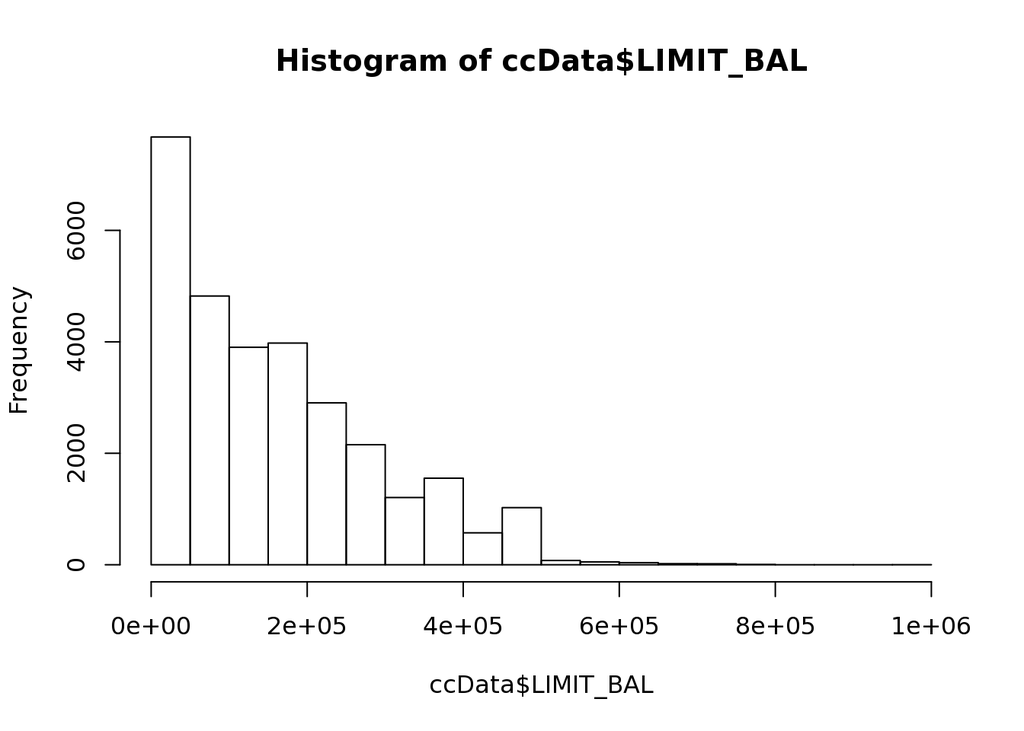

```r
hist(ccData$LIMIT_BAL)
```

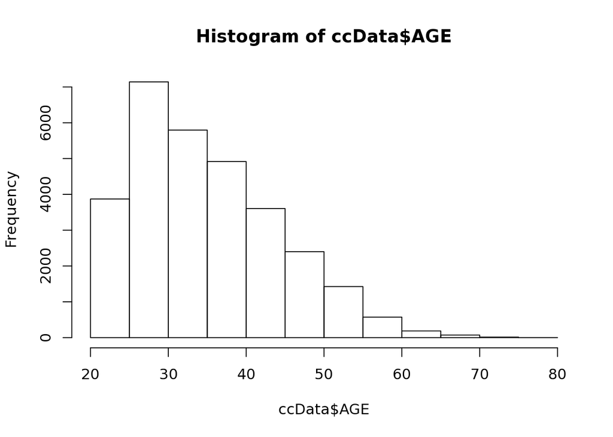

```r
#hist(ccData$SEX)
#hist(ccData$MARRIAGE)
hist(ccData$AGE)
```

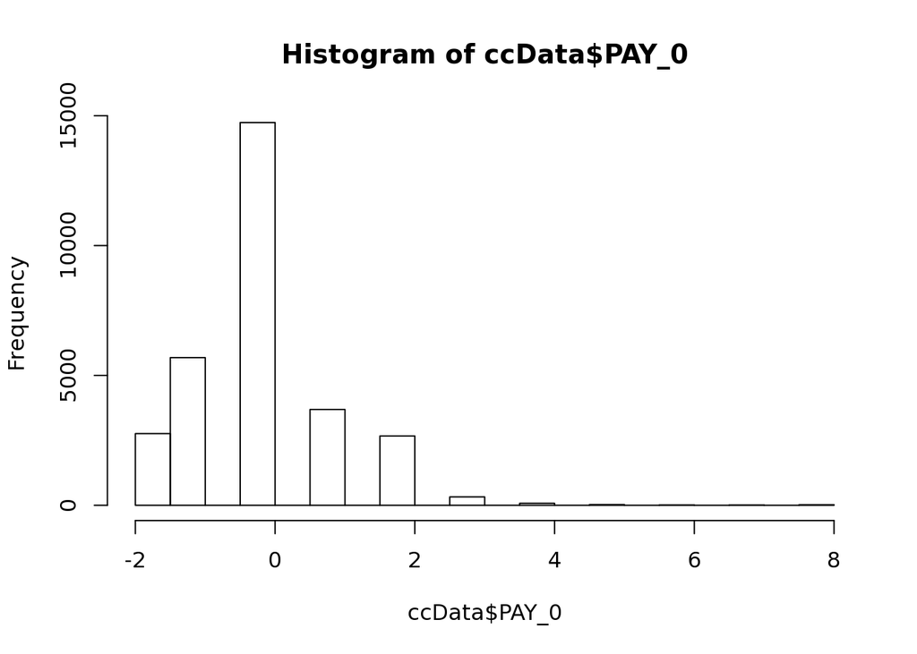

```r
hist(ccData$PAY_0)
```

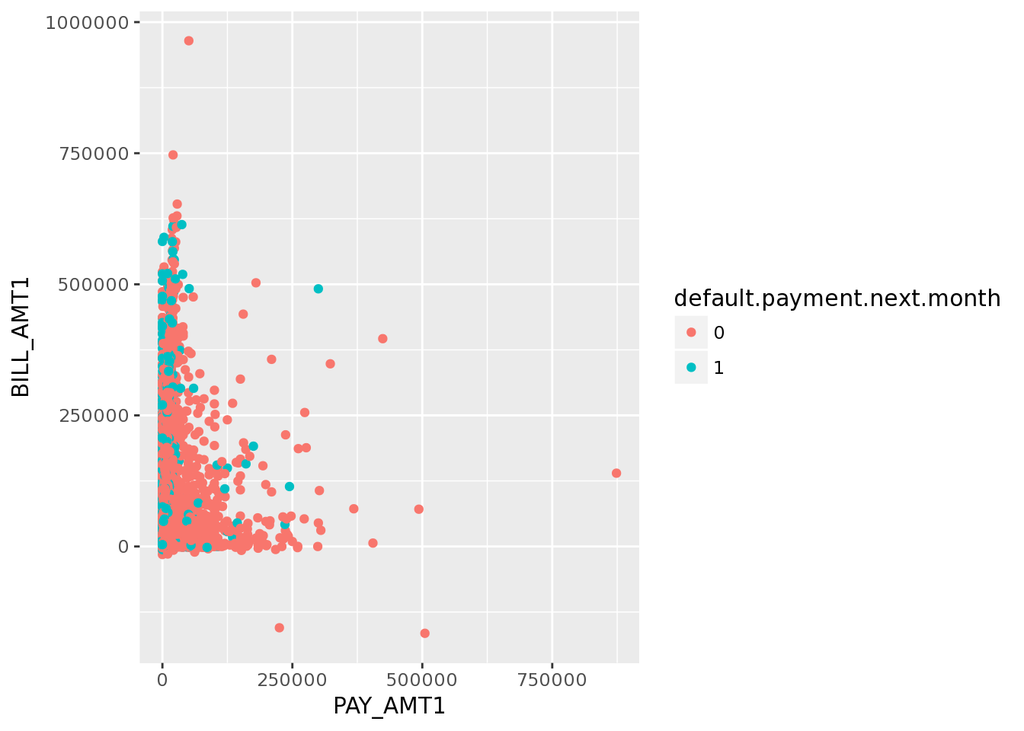

```r
#ggplot(ccData, aes(PAY_AMT1, fill=MARRIAGE)) +
#    geom_density(alpha=0.3)
qplot(PAY_AMT1,BILL_AMT1,data=ccData, col=default.payment.next.month)
```

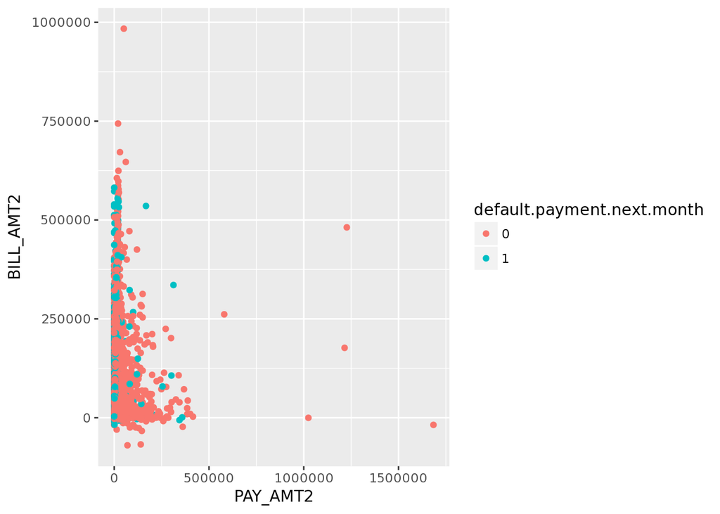

```r
qplot(PAY_AMT2,BILL_AMT2,data=ccData, col=default.payment.next.month)
```

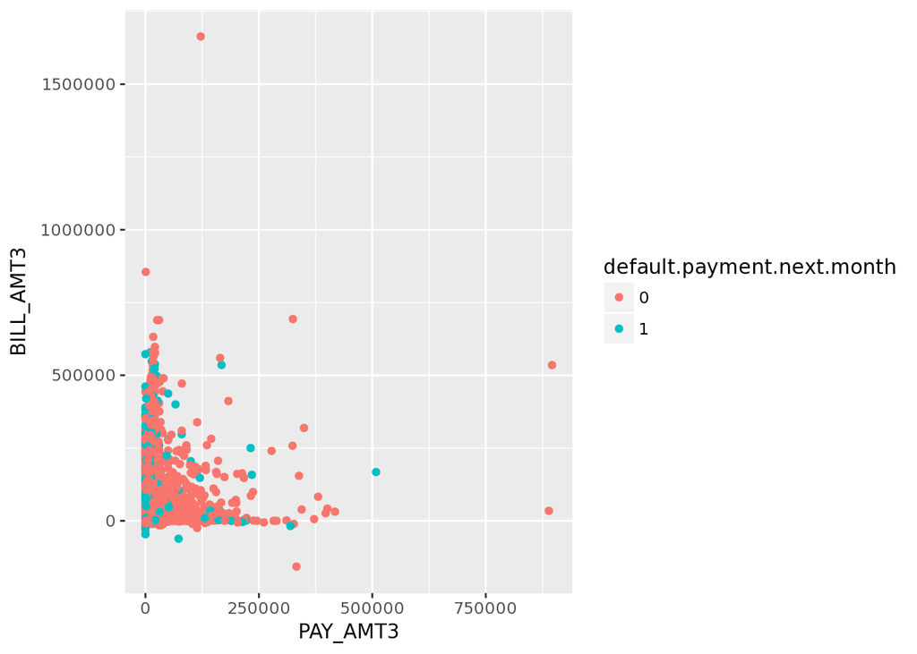

```r
qplot(PAY_AMT3,BILL_AMT3,data=ccData, col=default.payment.next.month)
```

## Parkinsons

This dataset is composed of a range of biomedical voice measurements from 31 people, 23 with Parkinson’s disease (PD). Each column in the table is a particular voice measure, and each row corresponds one of 195 voice recording from these individuals (“name” column). The main aim of the data is to discriminate healthy people from those with PD, according to “status” column which is set to 0 for healthy and 1 for PD.

There are around six recordings per patient, the name of the patient is identified in the first column.

Matrix column entries (attributes): name - ASCII subject name and recording number MDVP:Fo(Hz) - Average vocal fundamental frequency MDVP:Fhi(Hz) - Maximum vocal fundamental frequency MDVP:Flo(Hz) - Minimum vocal fundamental frequency MDVP:Jitter(%),MDVP:Jitter(Abs),MDVP:RAP,MDVP:PPQ,Jitter:DDP - Several measures of variation in fundamental frequency MDVP:Shimmer,MDVP:Shimmer(dB),Shimmer:APQ3,Shimmer:APQ5,MDVP:APQ,Shimmer:DDA - Several measures of variation in amplitude NHR,HNR - Two measures of ratio of noise to tonal components in the voice status - Health status of the subject (one) - Parkinson’s, (zero) - healthy RPDE,D2 - Two nonlinear dynamical complexity measures DFA - Signal fractal scaling exponent spread1,spread2,PPE - Three nonlinear measures of fundamental frequency variation

status - Health status of the subject (one) - Parkinson’s, (zero) - healthy

```
  MDVP.Fo.Hz.      MDVP.Fhi.Hz.    MDVP.Flo.Hz.    MDVP.Jitter...
 Min.   : 88.33   Min.   :102.1   Min.   : 65.48   Min.   :0.001680
 1st Qu.:117.57   1st Qu.:134.9   1st Qu.: 84.29   1st Qu.:0.003460
 Median :148.79   Median :175.8   Median :104.31   Median :0.004940
 Mean   :154.23   Mean   :197.1   Mean   :116.32   Mean   :0.006220
 3rd Qu.:182.77   3rd Qu.:224.2   3rd Qu.:140.02   3rd Qu.:0.007365
 Max.   :260.11   Max.   :592.0   Max.   :239.17   Max.   :0.033160
 MDVP.Jitter.Abs.       MDVP.RAP           MDVP.PPQ
 Min.   :7.000e-06   Min.   :0.000680   Min.   :0.000920
 1st Qu.:2.000e-05   1st Qu.:0.001660   1st Qu.:0.001860
 Median :3.000e-05   Median :0.002500   Median :0.002690
 Mean   :4.396e-05   Mean   :0.003306   Mean   :0.003446
 3rd Qu.:6.000e-05   3rd Qu.:0.003835   3rd Qu.:0.003955
 Max.   :2.600e-04   Max.   :0.021440   Max.   :0.019580
   Jitter.DDP        MDVP.Shimmer     MDVP.Shimmer.dB.  Shimmer.APQ3
 Min.   :0.002040   Min.   :0.00954   Min.   :0.0850   Min.   :0.004550
 1st Qu.:0.004985   1st Qu.:0.01650   1st Qu.:0.1485   1st Qu.:0.008245
 Median :0.007490   Median :0.02297   Median :0.2210   Median :0.012790
 Mean   :0.009920   Mean   :0.02971   Mean   :0.2823   Mean   :0.015664
 3rd Qu.:0.011505   3rd Qu.:0.03789   3rd Qu.:0.3500   3rd Qu.:0.020265
 Max.   :0.064330   Max.   :0.11908   Max.   :1.3020   Max.   :0.056470
  Shimmer.APQ5        MDVP.APQ        Shimmer.DDA           NHR
 Min.   :0.00570   Min.   :0.00719   Min.   :0.01364   Min.   :0.000650
 1st Qu.:0.00958   1st Qu.:0.01308   1st Qu.:0.02474   1st Qu.:0.005925
 Median :0.01347   Median :0.01826   Median :0.03836   Median :0.011660
 Mean   :0.01788   Mean   :0.02408   Mean   :0.04699   Mean   :0.024847
 3rd Qu.:0.02238   3rd Qu.:0.02940   3rd Qu.:0.06080   3rd Qu.:0.025640
 Max.   :0.07940   Max.   :0.13778   Max.   :0.16942   Max.   :0.314820
      HNR         status       RPDE             DFA
 Min.   : 8.441   0: 48   Min.   :0.2566   Min.   :0.5743
 1st Qu.:19.198   1:147   1st Qu.:0.4213   1st Qu.:0.6748
 Median :22.085           Median :0.4960   Median :0.7223
 Mean   :21.886           Mean   :0.4985   Mean   :0.7181
 3rd Qu.:25.076           3rd Qu.:0.5876   3rd Qu.:0.7619
 Max.   :33.047           Max.   :0.6852   Max.   :0.8253
    spread1          spread2               D2             PPE
 Min.   :-7.965   Min.   :0.006274   Min.   :1.423   Min.   :0.04454
 1st Qu.:-6.450   1st Qu.:0.174350   1st Qu.:2.099   1st Qu.:0.13745
 Median :-5.721   Median :0.218885   Median :2.362   Median :0.19405
 Mean   :-5.684   Mean   :0.226510   Mean   :2.382   Mean   :0.20655
 3rd Qu.:-5.046   3rd Qu.:0.279234   3rd Qu.:2.636   3rd Qu.:0.25298
 Max.   :-2.434   Max.   :0.450493   Max.   :3.671   Max.   :0.52737
```

Let’s take a look at some plots

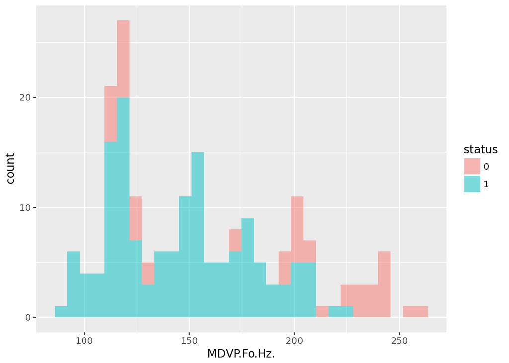

```r
qplot(MDVP.Fo.Hz., fill=status, alpha=I(.5), data=pdData)
```

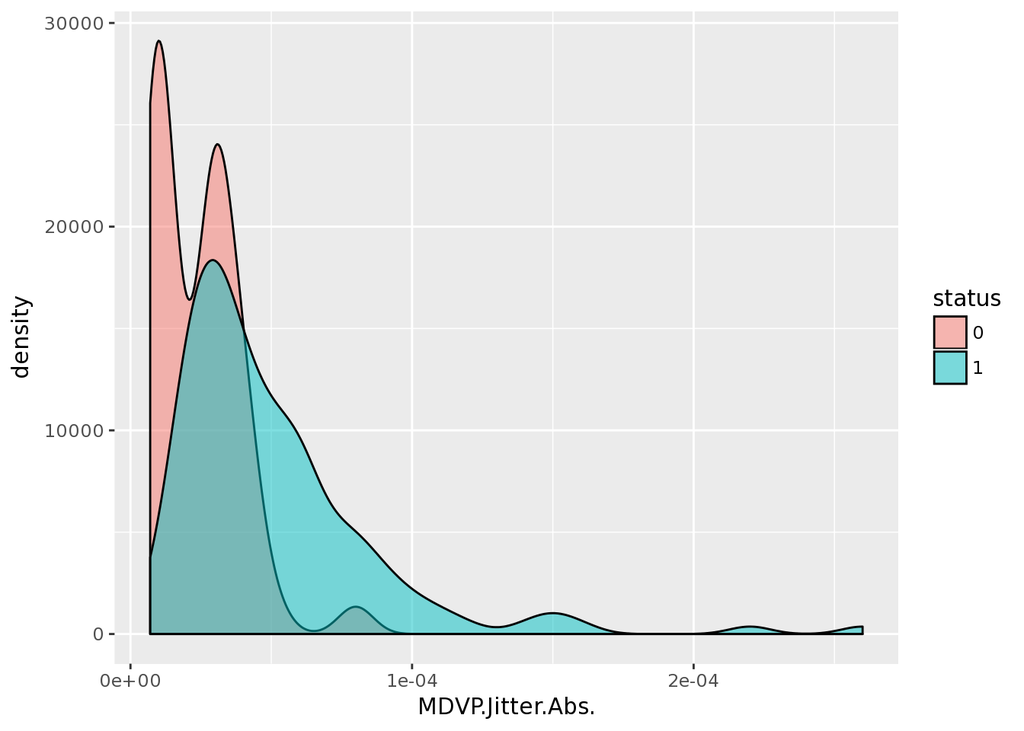

```r
qplot(MDVP.Jitter.Abs., fill=status, alpha=I(.5), geom="density", data=pdData)
```

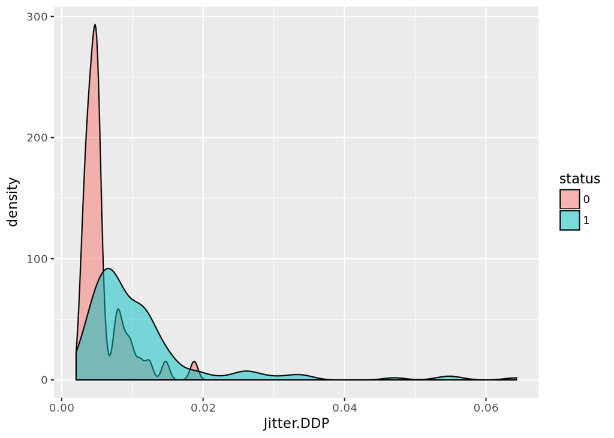

```r
qplot(Jitter.DDP, fill=status, alpha=I(.5), geom="density", data=pdData)
```

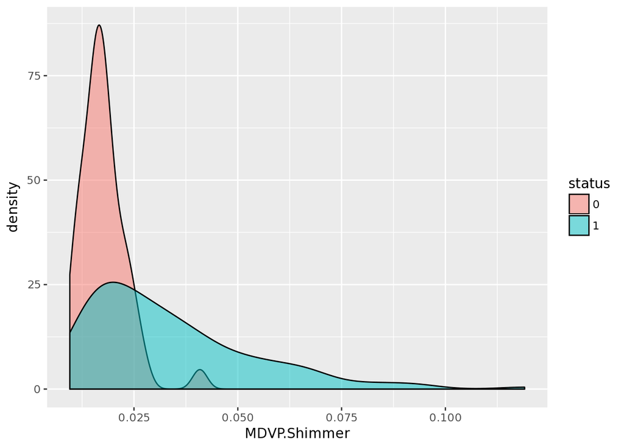

```r
qplot(MDVP.Shimmer, fill=status, alpha=I(.5), geom="density", data=pdData)
```

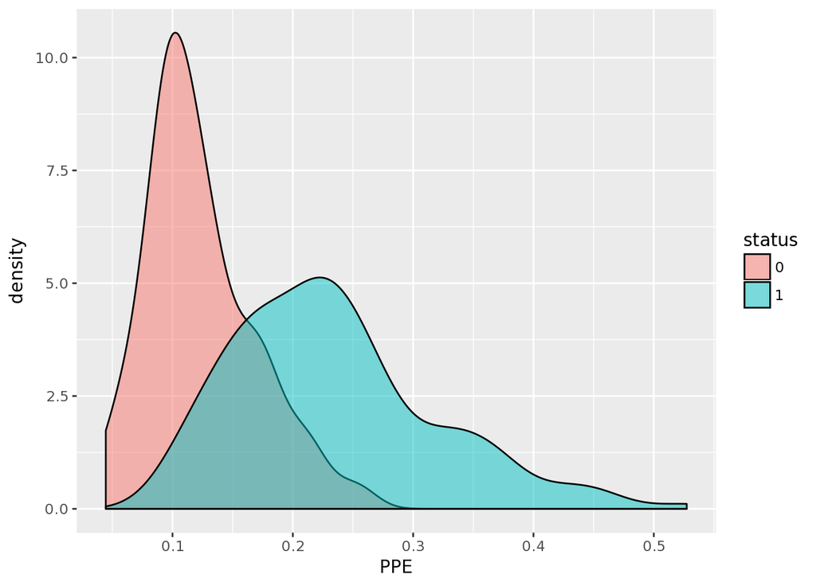

```r
qplot(PPE, fill=status, alpha=I(.5), geom="density", data=pdData)
```

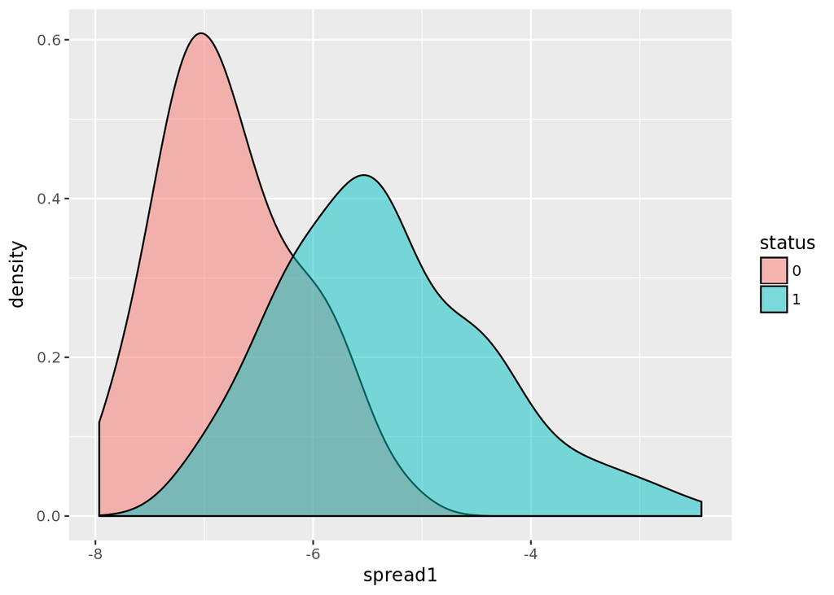

```r
qplot(spread1, fill=status, alpha=I(.5), geom="density", data=pdData)
```

Lets look at some correlations

```r
variablesNumeric <- sapply(pdData, is.numeric) # both numeric integers
DT <- data.table(pdData)
corrData <- DT[, ..variablesNumeric]
corMatrix <- cor(corrData)
corTable <- setDT(melt(corMatrix))[order(-value)][value!=-1]
corTableStatus <- corTable[Var1=="status",][order(-value)]
corTableHigh <- corTable[value > 0.8 | value < - 0.8][order(Var1,-value)]
print(corTableHigh)
```

```
               Var1           Var2     value
  1:    MDVP.Fo.Hz.    MDVP.Fo.Hz. 1.0000000
  2:   MDVP.Fhi.Hz.   MDVP.Fhi.Hz. 1.0000000
  3:   MDVP.Flo.Hz.   MDVP.Flo.Hz. 1.0000000
  4: MDVP.Jitter... MDVP.Jitter... 1.0000000
  5: MDVP.Jitter...     Jitter.DDP 0.9902762
 ---
 98:        spread1            PPE 0.9624353
 99:        spread2        spread2 1.0000000
100:             D2             D2 1.0000000
101:            PPE            PPE 1.0000000
102:            PPE        spread1 0.9624353
```

TODO - understand how to get the self-correlation removed

## References

Max A. Little, Patrick E. McSharry, Eric J. Hunter, Lorraine O. Ramig (2008), ‘Suitability of dysphonia measurements for telemonitoring of Parkinson’s disease’, IEEE Transactions on Biomedical Engineering (to appear).

‘Exploiting Nonlinear Recurrence and Fractal Scaling Properties for Voice Disorder Detection’, Little MA, McSharry PE, Roberts SJ, Costello DAE, Moroz IM. BioMedical Engineering OnLine 2007, 6:23 (26 June 2007)

## Save Formatted Data

Finally Save the datasets

```r
Sys.time()
```

```
[1] "2018-05-11 23:14:30 UTC"
```

```r
save(ccData, file="./data/ccData.RData")
save(pdData, file="./data/pdData.RData")
```